# Enzyme utilization and saturation for *R. eutropha*

30 October, 2020

## Description

This R notebook is a bioinformatics pipeline to **analyze protein saturation/under-utilization with a resource allocation model** for the chemolithoautotroph *Ralstonia eutropha* (a.k.a. *Cupriavidus necator*).

## Libraries

```r
# loading libraries
library(lattice)
library(latticeExtra)
library(latticetools)
library(tidyverse)
library(stringi)
```

## Data import

Define the data source directories. Some of them are external in the sense of not included in the accompanying data folder of this R notebook. These are located in the accompanying github repository for the resource allocation model that was used here. The resource allocation model can be found at my fork of Bacterial-RBA-models.

```r
Reutropha_proteomics <- "~/Documents/SciLifeLab/Resources/R_projects/ShinyProt/data/Ralstonia_eutropha.Rdata"
model_reactions <- "../../Ralstonia-model-constraints/data/input/model_reactions.csv"
simulation_dir <- "~/Documents/SciLifeLab/Resources/Models/Bacterial-RBA-models/Ralstonia-eutropha-H16/simulation/substrate_limitation/"
source("read_rba_result.R")
```

Read simulation data.

```r
# read simulation results
df_flux <- read_rba_result(list.files(simulation_dir, pattern = "fluxes_.*.tsv$", full.names = TRUE))
df_prot <- read_rba_result(list.files(simulation_dir, pattern = "proteins_.*.tsv", full.names = TRUE))
df_macr <- read_rba_result(list.files(simulation_dir, pattern = "macroprocesses_.*.tsv", full.names = TRUE))
```

## Overview on substrate uptake, growth, and yield

After running a set of simulations in RBApy that simulate increasing substrate limitation, we can plot the substrate uptake rate `q`, yield `Y` in gram biomass per gram substrate, and growth rate `µ`. Unlike genome scale models, growth becomes limited by the maximum amount of proteins that a cell can synthesize. If cells would not be protein-limited, *or* proteins would catalyze reactions infinitely fast, no such limitation would take place and growth rate would scale linearly with substrate concentration. This is the situation in FBA simulation.

```r
# rearrange some rows (mu, qS) to columns
df_macr <- df_macr %>% filter(!grepl("test_process", key)) %>%
  spread(key, value) %>%

  # add type of simulation
  mutate(substrate = case_when(
    carbon_source == "for" ~ "formate",
    carbon_source == "succ" ~ "succinate",
    carbon_source == "fru" & nitrogen_conc == 1 ~ "fructose",
    carbon_source == "fru" & nitrogen_conc != 1 ~ "ammonium"
  )) %>%

  # add uptake rate in g/gDCW*h instead of mmol
  mutate(qS_g_gDCW_h = case_when(
    substrate == "formate" ~ qS*0.04603,
    substrate == "succinate" ~ qS*0.11809,
    substrate == "fructose" ~ qS*0.18016,
    substrate == "ammonium" ~ qS*0.05349
  ))
```

First we can have a look at how growth rate levels off with increasing substrate *concentration* in mmol/L. Note: this is not equal to *substrate uptake rate*. Substrate uptake rate and growth rate should have an almost linear relationship.

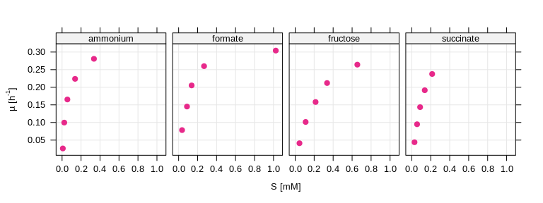

```r
# copy nitrogen to carbon concentration for ammonium limitation,
# just for plotting purposes
df_macr %>%
  mutate(carbon_conc = case_when(
    substrate == "ammonium" ~ nitrogen_conc,
    TRUE ~ carbon_conc
  )) %>%

  xyplot(mu ~ carbon_conc | substrate, .,
    par.settings = custom.colorblind(),
    between = list(x = 0.5, y = 0.5),
    layout = c(4,1), lwd = 1.5, pch = 19,
    xlab = expression("S [mM]"),
    ylab = expression('µ [h'^'-1'*']'),
    scales = list(alternating = FALSE),
    panel = function(x, y, ...) {
      panel.grid(h = -1, v = -1, col = grey(0.9))
      panel.xyplot(x, y, cex = 0.9, ...)
    }
  )
```

Create a Herbert-Pirt plot for each condition (growth rate versus substrate uptake rate). This plot would show a change in yield by a ‘kink’ of the data points.

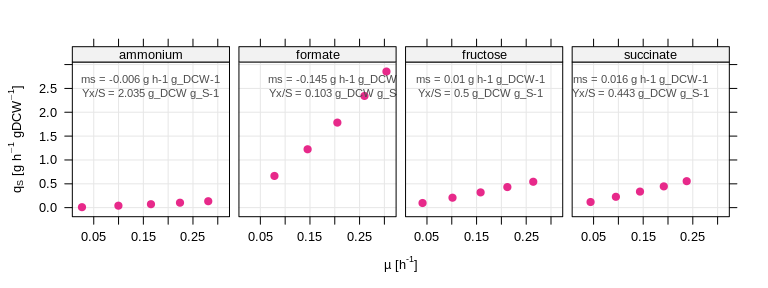

```r
xyplot(qS_g_gDCW_h ~ mu | substrate, df_macr,
  par.settings = custom.colorblind(),
  between = list(x = 0.5, y = 0.5),
  layout = c(4,1), lwd = 1.5, pch = 19,
  ylab = expression("q"[S]*" [g h"^-1*" gDCW"^-1*"]"),
  xlab = expression('µ [h'^'-1'*']'),
  scales = list(alternating = FALSE),
  panel = function(x, y, ...) {
    panel.grid(h = -1, v = -1, col = grey(0.9))
    panel.xyplot(x, y, cex = 0.9, ...)
    # displaying maintenance and yield coefficients
    coef <- lm(y ~ x, data.frame(x, y))$coeff
    panel.text(median(x), 2.7,
      paste("ms =", round(coef[[1]], 3), "g h-1 g_DCW-1"),
      col = grey(0.3), cex = 0.7)
    panel.text(median(x), 2.4, paste(expression("Yx/S ="),
        round(1/coef[[2]], 3), "g_DCW g_S-1"),
      col = grey(0.3), cex = 0.7)
  }
)
```

## Resource allocation in terms of protein mass

To determine the true allocation of protein resources per compartment, but also the true cost of protein per process, we need to **convert the predicted concentration of proteins in mmol per gDCW to g per gDCW**, simply by multiplying protein concentration with the molecular weight of a protein (g/mol, converted to g/mmol). We can then also easily transform g/gDCW to mass fraction by dividing individual protein concentrations by the sum of all protein concentrations. The protein mass fraction is dimensionless. The only parameter required for this transformation is the molecular weight per protein which is available from uniprot. We can for example take the protein annotation table that is automatically downloaded during `RBApy` model generation.

```r
# import downloaded Ralstonia protein annotation from uniprot
df_uniprot <- read_tsv(paste0(simulation_dir, "../../data/uniprot.csv"), col_types = cols()) %>%
  mutate(locus_tag = stri_extract_first(`Gene names`, regex = "H16_[AB][0-9]{4}|PHG[0-9]{3}"))

# merge predicted protein allocation with molecular weight info from uniprot
df_prot <- left_join(df_prot, select(df_uniprot, locus_tag, Length, Mass),
  by = c("key" = "locus_tag")) %>%

  # calculate predicted protein mass in g/gDCW using MW in g/mmol, and mass fraction
  group_by(simulation) %>% mutate(
    predicted_mass_g_gDCW = value * Mass / 1000)

# test if mass fractions sum to reasonable value
df_prot %>% summarize(
  predicted_mass_g_gDCW = sum(predicted_mass_g_gDCW, na.rm = TRUE))
```

| simulation | predicted_mass_g_gDCW |
| --- | --- |
| for_0.036000000000000004_nh4_1.0_14 | 0.06800198 |
| for_0.08800000000000001_nh4_1.0_13 | 0.09101824 |
| for_0.13699999999999998_nh4_1.0_12 | 0.13497394 |
| for_0.268_nh4_1.0_11 | 0.17921746 |
| for_1.024_nh4_1.0_10 | 0.20856543 |
| fru_0.045_nh4_1.0_4 | 0.04430259 |
| fru_0.11_nh4_1.0_3 | 0.07815843 |
| fru_0.215_nh4_1.0_2 | 0.07721529 |
| fru_0.336_nh4_1.0_1 | 0.09971868 |
| fru_0.655_nh4_1.0_0 | 0.12178587 |

[output cut: 10 more lines]

The simulated protein mass per gDCW changes with growth rate, and it is considerably lower then the estimated ~0.65-0.68 g total protein/gDCW that was previously estimated for bacteria (see e.g. Park et al., biomass composition for *Ralstonia eutropha* model, or Touloupakis et al., biomass composition for cyanobacteria). One reason is that above numbers only include enzymatic proteins (the ones represented by the GSM). For machinery such as ribosomal proteins, a separate calculation needs to be performed. The model returns estimated concentration of machineries for replication, transcription, translation, and protein folding. The associated proteins can be imported from the model folder and the total mass estimated using molecular weight and subunit stoichiometry as done before for enzymatic proteins.

```r
machinery_names <- c("replication", "transcription", "ribosome", "chaperones")
machinery_tables <- paste0(simulation_dir, "../../data/", machinery_names, ".tsv")

df_macr <- df_macr %>%

  # remove unused columns and rename important ones
  select(-P_ENZ, -P_RNADEG) %>%
  rename(replication = P_REP, transcription = P_TSC,
    ribosome = P_TA, chaperones = P_CHP, substrate_uptake_rate = qS,
    predicted_growth_rate = mu
  ) %>%

  # gather individual machineries in one column
  gather(key = machine, value = predicted_mass_mmol_gDCW,
    chaperones:transcription) %>%

  # round utake rates for merging
  mutate(substrate_uptake_rate = round(substrate_uptake_rate, 3))


df_machinery <- lapply(machinery_tables, read_tsv) %>% bind_rows(.id = "machine") %>%
  mutate(machine = recode(machine, !!!setNames(machinery_names, 1:4))) %>%
  select(-`Entry name`, -Sequence, -Cofactor, -`EC number`, -`Organism ID`, `Organism`,
    -`Catalytic activity`, -Status) %>%

  # join with prediction of molecular machine concentration (mmol/gDCW)
  left_join(df_macr, by = "machine") %>%

  # calculate predicted protein mass in g/gDCW using MW in g/mmol, and mass fraction
  group_by(simulation) %>% mutate(
    predicted_mass_g_gDCW = predicted_mass_mmol_gDCW * Stoichiometry * Mass / 1000
  )

# test if mass fractions sum to reasonable value
df_machinery %>%
  summarize(sum_g_gDCW = sum(predicted_mass_g_gDCW, na.rm = TRUE)) %>%
  ungroup %>% head(10)
```

| simulation | sum_g_gDCW |
| --- | --- |
| for_0.036000000000000004_nh4_1.0_14 | 0.02254203 |
| for_0.08800000000000001_nh4_1.0_13 | 0.04313465 |
| for_0.13699999999999998_nh4_1.0_12 | 0.06682645 |
| for_0.268_nh4_1.0_11 | 0.08873268 |
| for_1.024_nh4_1.0_10 | 0.09313270 |
| fru_0.045_nh4_1.0_4 | 0.01111059 |
| fru_0.11_nh4_1.0_3 | 0.02894135 |
| fru_0.215_nh4_1.0_2 | 0.04449138 |
| fru_0.336_nh4_1.0_1 | 0.06248504 |
| fru_0.655_nh4_1.0_0 | 0.07695839 |

## Correlation between predicted and experimentally determined proteome

To compare the predicted and experimental proteome composition, we load the required proteomics data. Proteomics data are mass spectrometry measurements with label-free quantification of peptides. Protein quantification was performed by summing up all peptide intensities per annotated protein. The proteomic measurement unit, mass fraction, can be easily transformed to g/gDCW by multiplying mass fraction with the total protein mass (0.68 g/gDCW) used in RBApy simulations. Or *vice versa* by converting RBApy protein concentration (mmol/gDCW) to mass fraction.

To allow a fair comparison between measured and predicted data, it is necessary to aggregate (e.g. sum up) all protein abundances allocated to one reaction. The reason is that the model will only predict **protein abundance of the first of a range of iso-enzymes** for a particular reaction, while in reality another iso-enzyme might be more abundant (carry the majority of flux). This would lead to lower correlation between measured and predicted protein concentrations. This is not necessary for machinery proteins, they have no iso-enzymes and are used under all conditions.

### Combine simulations and experimental data

The proteomics data must be merged with `RBApy` simulation results using matching conditions. First, proteomics data are loaded and prepared for merging.

**Step 1: load proteomics data**

```r
load(Reutropha_proteomics)

# pick a condition matching simulations
Ralstonia_eutropha <- Ralstonia_eutropha %>%

  # round substrate uptake rate
  mutate(substrate_uptake_rate = round(substrate_uptake_rate, 3)) %>%
  # manually alter one rate for mapping to simulation
  mutate(substrate_uptake_rate = substrate_uptake_rate %>% replace(., . == 63.030, 62.0)) %>%

  # select only required columns
  rename(growth_rate = growthrate) %>%
  select(uniprot, locus_tag, protein, condition, substrate, substrate_uptake_rate,
    growth_rate, COG_Process, R1:R4) %>%

  # turn raw intensity measurements into mass in g per gDCW (assuming a
  # total protein concentration of 0.68 g/gDCW)
  group_by(condition) %>%
  mutate(across(matches("R[1234]"), function(x) x/sum(x, na.rm = TRUE)*0.68)) %>%
  gather(key = "replicate", value = "mass_g_gDCW", R1:R4)
```

**Step 2: Load gene reaction associations obtained from genome scale model**

```r
df_model_reactions <- read_csv(model_reactions, col_types = cols()) %>%

  # filter for reactions with gene associations
  select(reaction_id, reaction_name, genes, groups) %>% separate_rows(genes, sep = ", ") %>%
  filter(!is.na(genes)) %>%
  rename(model_group = groups) %>%

  # add a more general groups description
  mutate(model_group_basic = case_when(
    grepl("Phenylala|Valine|Tyrosine|Glutamate|Glycine|Tryptophan|Methionine|
          Cysteine|Alanine|Histidine|Arginine|Lysine", model_group) ~ "Amino acid",
    grepl("Pentose|Calvin", model_group) ~ "PPP + Calvin cycle",
    model_group == "Citric Acid Cycle" ~ "Citric Acid Cycle",
    model_group == "Glycolysis/Gluconeogenesis" ~ "Glycolysis/Gluconeogenesis",
    model_group == "Glyoxylate and Dicarboxylate metabolism" ~ "Autotrophic energy",
    model_group == "Oxidative Phosphorylation" ~ "Oxidative Phosphorylation",
    TRUE ~ "Other"
  ))
```

**Step 3: Select and rename conditions from RBA simulation**

```r
# add type of substrate limitation
add_cond <- function(df) {
  df %>% mutate(substrate = case_when(
    carbon_source == "succ" ~ "succinate",
    carbon_source == "for" ~ "formate",
    carbon_source == "fru" & nitrogen_conc == 1 ~ "fructose",
    TRUE ~ "ammonium",
  ))
}

# add substrate uptake rate
df_substrate_uptake <- filter(df_macr, !duplicated(sim_run)) %>%
  select(sim_run, substrate_uptake_rate)
df_prot <- df_prot %>% add_cond %>% left_join(df_substrate_uptake)
df_flux <- df_flux %>% add_cond %>% left_join(df_substrate_uptake)
```

**Step 4: Merge protein measurements and predictions into master tables**

The first step is to merge the tables for machinery proteins, that means proteins related to replication, transcription, translation, and protein folding. These don’t require allocation of protein mass to reactions, and merging becomes simply an operation on enzyme IDs and conditions.

```r
# join with proteomics data
df_machinery <- df_machinery %>%
  left_join(Ralstonia_eutropha,
    by = c("Entry" = "uniprot", "substrate", "substrate_uptake_rate"))
```

The second table for all enzymatic proteins requires the allocation of estimated protein mass to enzymes. One option for the future is to retrieve these values directly from RBApy, but this is not implemented yet.

```r
df_prot_comp <- df_model_reactions %>%

  # join with proteomics data
  left_join(Ralstonia_eutropha, by = c("genes" = "locus_tag")) %>%

  # join with simulation data
  left_join(df_prot, by = c("genes" = "key", "substrate", "substrate_uptake_rate")) %>%

  # determine number of reactions per protein
  group_by(condition, genes, replicate) %>%
  mutate(n_reactions = length(reaction_id)) %>%

  # calculate protein mass in g/gDCW
  ungroup %>% mutate(
    predicted_mass_g_gDCW = predicted_mass_g_gDCW/n_reactions,
    mass_g_gDCW = mass_g_gDCW/n_reactions
  ) %>%

  # summarize by summing up protein abundance per reaction (NA treated as zero)
  group_by(condition, reaction_id, reaction_name, model_group, model_group_basic, substrate, substrate_uptake_rate,
    growth_rate, replicate) %>%
  summarize(
    predicted_mass_g_gDCW = sum(predicted_mass_g_gDCW, na.rm = TRUE),
    mass_g_gDCW = sum(mass_g_gDCW, na.rm = TRUE)
  ) %>%

  # add predicted growth rate to experimental
  left_join(
    df_machinery %>% ungroup %>%
    select(substrate, substrate_uptake_rate, predicted_growth_rate) %>%
    filter(!duplicated(substrate_uptake_rate))
  ) %>%

  # add predicted fluxes per reaction and condition
  left_join(
    df_flux %>% ungroup %>%
    select(key, value, substrate, substrate_uptake_rate) %>%
    rename(reaction_id = key, flux_mmol_gDCW_h = value)
  )
```

Now we perform a test. We check if all protein abundances allocated to reactions sum to a reasonable value as we would expect. This value would be the total *enzymatic* protein mass in g/gDCW, per condition and replicate, and could reach up to 0.2 g/gDCW for the simulations, and higher for the actual data (includes all additional proteins quantified in experiment, but not carrying flux in model simulations).

```r
df_prot_comp %>% group_by(condition, replicate) %>%
  filter(predicted_mass_g_gDCW != 0) %>%
  summarize(sum(mass_g_gDCW), sum(predicted_mass_g_gDCW))
```

| condition | replicate | sum(mass_g_gDCW) | sum(predicted_mass_g_gDCW) |
| --- | --- | --- | --- |
| FA 0.05 | R1 | 0.1715547 | 0.06490325 |
| FA 0.05 | R2 | 0.1835826 | 0.06490325 |
| FA 0.05 | R3 | 0.1880993 | 0.06490325 |
| FA 0.05 | R4 | 0.1888955 | 0.06490325 |
| FA 0.1 | R1 | 0.2016430 | 0.08523844 |
| FA 0.1 | R2 | 0.2062520 | 0.08523844 |
| FA 0.1 | R3 | 0.1887384 | 0.08523844 |
| FA 0.1 | R4 | 0.2156255 | 0.08523844 |
| FA 0.15 | R1 | 0.2196741 | 0.12665785 |
| FA 0.15 | R2 | 0.2259941 | 0.12665785 |

[output cut: 70 more lines]

The total predicted protein mass is lower than the measured protein mass. Therefore the following section quantifies discrepancies between model predicted and actually measured abundances. First we can inspect the top N reactions with highest **average predicted protein abundance**. The ratio of predicted divided by measured mass indicates that a handful of proteins are predicted to be more than 10 fold abundant compared to the measured abundance. This points towards fluxes being erroneously predicted too high for particular reactions, or *k_app* values being estimated too low for the estimated flux.

However, the largest discrepancies arise from **under-estimation of proteins**, the main cause being that the model predicts the **optimal abundance for each enzyme to carry a certain flux** (see following figure, comparison of simulation and experiment). If fluxes are drastically reduced due to strong substrate limitation, the minimal required protein abundance to optimize growth will be much lower than the measured abundance. A bacterial cell on the other hand can not fully reduce its proteome but instead ‘suspends’ inactive enzymes.

```r
# Proteins 'over-predicted' by more than 10x are rare
df_prot_comp %>% group_by(reaction_id, substrate) %>%
  summarize(
    average_predicted_mass = mean(predicted_mass_g_gDCW),
    average_measured_mass = mean(mass_g_gDCW),
    overprediction_fold = round(average_predicted_mass/average_measured_mass)) %>%
  arrange(desc(overprediction_fold)) %>% filter(overprediction_fold > 10)
```

| reaction_id | substrate | average_predicted_mass | average_measured_mass | overprediction_fold |
| --- | --- | --- | --- | --- |
| PGRPP | formate | 1.260147e-07 | 3.075945e-09 | 41 |
| GLYAT | formate | 1.938895e-03 | 4.966273e-05 | 39 |
| PCT1 | fructose | 7.242025e-04 | 2.479545e-05 | 29 |
| PCT2 | fructose | 7.242025e-04 | 2.479545e-05 | 29 |
| PCT3 | fructose | 7.242025e-04 | 2.479545e-05 | 29 |
| THRD | formate | 4.939076e-05 | 1.825483e-06 | 27 |
| GCLDH | succinate | 1.045714e-06 | 4.275903e-08 | 24 |
| HPYRRx | succinate | 1.045714e-06 | 4.275903e-08 | 24 |
| PCT1 | succinate | 7.004343e-04 | 4.790244e-05 | 15 |
| PCT2 | succinate | 7.004343e-04 | 4.790244e-05 | 15 |

[output cut: 4 more lines]

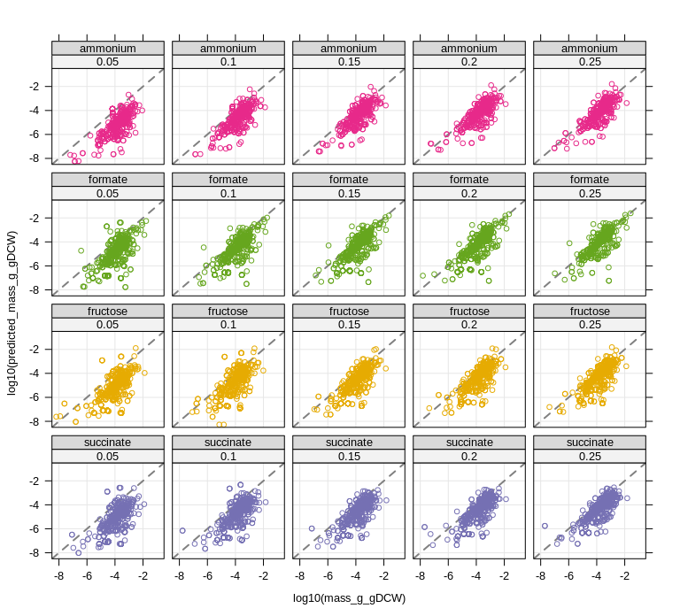

```r
# comparison of simulation and experiment
df_prot_comp %>% group_by(reaction_id, substrate, growth_rate) %>%
  summarize(predicted_mass_g_gDCW = mean(predicted_mass_g_gDCW),
    mass_g_gDCW = mean(mass_g_gDCW)
  ) %>%

  xyplot(log10(predicted_mass_g_gDCW) ~ log10(mass_g_gDCW) | factor(growth_rate) * substrate, .,
    groups = substrate,
    par.settings = custom.colorblind(), cex = 0.7,
    scales = list(alternating = FALSE), as.table = TRUE,
    between = list(x = 0.5, y = 0.5),
    pch = 1, xlim = c(-8.5, -0.5), ylim = c(-8.5, -0.5),
    panel = function(x, y, ...) {
      panel.grid(h = -1, v = -1, col = grey(0.9))
      panel.abline(a = 0, b = 1, col = grey(0.5), lty = 2, lwd = 2)
      panel.xyplot(x, y, ...)
    }
  )
```

### Change of machinery proteins with growth rate

The simulation and measurement data was prepared and merged by condition in the previous sections. Now it can be plotted to e.g. compare protein allocation over growth rate. Interestingly, we see that model predictions are quite accurately reflecting the range of protein allocation for the four different machineries, see following paragraphs. This is a good confirmation of the model’s predictive power, given that the rates of these machineries were *not fitted* from data but taken purely from literature. There are however some deviations from the predicted ‘optimal’ proteome:

- the most important machine is the ribosome. Prediction and experiment show a very similar increase of ribosome abundance with growth rate (slope of linear model), but the intersection (amount of unused ribosomes at zero growth) is much higher in experiment
- chaperones show an inverse proportional relationship with growth rate contrary to model prediction. Do (some of?) these proteins have another role than just folding, like stress response?
- transcription sector is quite stable, however, requires more enzymes than expected. Abundance is underestimated by 1 order of magnitude (5x10^-3 vs 5x10^-4 g/gDCW)
- replication sector is heavily underestimated by 3 orders of magnitude (10^-3 vs 10^-6 g/gDCW)

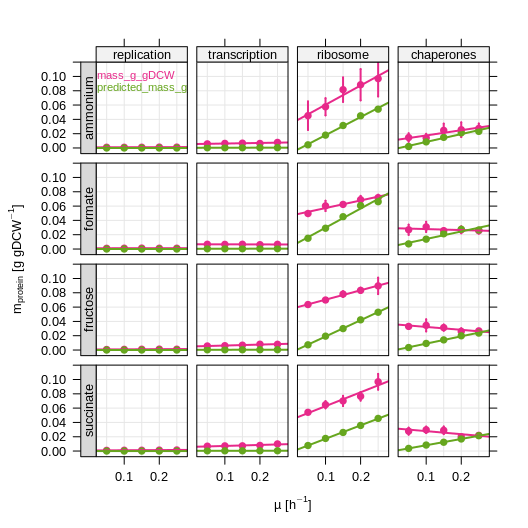

```r
plot_machinery <- df_machinery %>%

  # summing up protein mass over all conditions
  group_by(machine, substrate, growth_rate, replicate) %>%
  summarize(
    mass_g_gDCW = sum(mass_g_gDCW, na.rm = TRUE),
    predicted_mass_g_gDCW = sum(predicted_mass_g_gDCW, na.rm = TRUE)
  ) %>% ungroup %>%

  # replace 0 with NA and reorder factors
  mutate(across(matches("mass_g_gDCW"), ~ na_if(.x, 0))) %>%
  mutate(machine = machine %>% factor(., unique(.)[c(2,4,3,1)])) %>%

  xyplot_errbars(
    variables = "mass_g_gDCW + predicted_mass_g_gDCW ~
      factor(growth_rate) | machine * substrate",
    xlab = expression("µ [h"^-1*"]"),
    ylab = expression("m"[protein]*" [g gDCW"^-1*"]"),
    lmline = TRUE,
    scaleoptions = list(alternating = FALSE, x = list(at = c(2,4)))
  ) %>% useOuterStrips

print(plot_machinery)
```

The protein allocation for the two low-abundant machines, replication and transcription is very hard to see. We can update the Y-axis limits for this plot and replot it, a simple way to ‘zoom in’ 10-fold. By doing so, we notice that abundance of replication machinery increases with growth rate from 0.0010 to a maximum of 0.0015 g/gDCW, an increase by 20-50%. For transcription, abundance increases with growth rate from 0.006 to 0.008 g/gDCW, an increase of 33%.

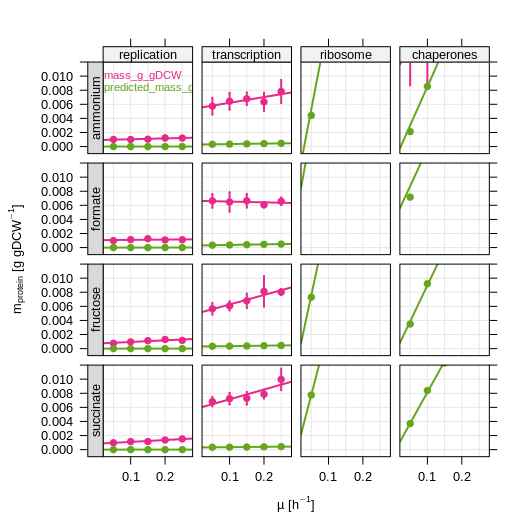

```r
update(plot_machinery, ylim = c(-0.001, 0.012))
```

### Under-utilization of machinery proteins

Here, we determine the *underutilized machinery fraction* by subtracting the simulated optimal protein allocation from the experimentally measured. This can also lead to negative values if less protein is present than predicted. Utilization is shown as percentage of available (experimentally determined) protein concentration.

```r
plot_machinery_util <- df_machinery %>%

  # summarizing protein utilization for all machines
  mutate(machine = "all") %>%
  group_by(machine, substrate, growth_rate, replicate) %>%
  summarize(
    mass = sum(mass_g_gDCW, na.rm = TRUE),
    predicted_mass = sum(predicted_mass_g_gDCW, na.rm = TRUE),
    percent_utilization = predicted_mass/(mass)
  ) %>%

  # remove 1 non-quantified replicate
  filter(!(substrate == "fructose" & growth_rate == 0.1 & replicate == "R2")) %>%

  # plot
  xyplot(percent_utilization ~ factor(growth_rate) | machine * substrate, .,
    par.settings = custom.colorblind(), ylim = c(0, 1),
    scales = list(y = list(draw = FALSE), x = list(at = c(2,4))),
    xlab = expression("µ [h"^-1*"]"), ylab = "",
    as.table = TRUE, between = list(x = 0.5, y = 0.5),
    pch = 19, lwd = 2, layout = c(1, 4),
    panel = function(x, y, ...) {
      panel.grid(h = -1, v = -1, col = grey(0.9))
      x_mean = unique(x); y_mean = tapply(y, x, mean)
      panel.xyarea(c(0, x_mean, 6), c(0, y_mean, tail(y_mean, 1)),
        lty = 0, col = grey(0.6, alpha = 0.5), ...)
      panel.errbars(x, y, ewidth = 0, col = grey(0.5), ...)
    }
  ) %>% useOuterStrips

print(plot_machinery, position = c(0, 0, 0.82, 1), more = TRUE)
print(plot_machinery_util, position = c(0.79, 0, 1, 1.))
```

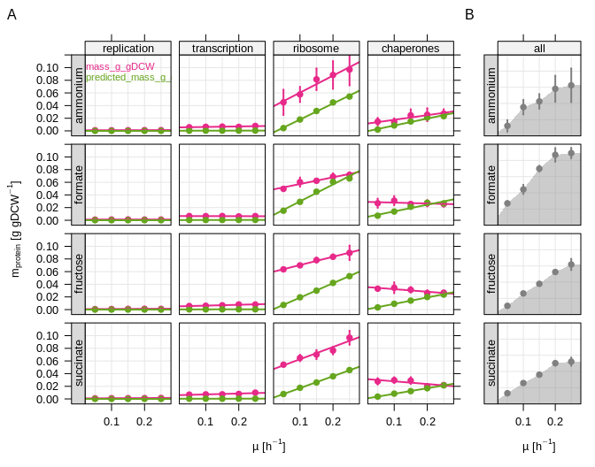

```r
grid::grid.text(c("A", "B"), x = c(0.02, 0.79), y = c(0.97,0.97))
```

### Chaperones show inverted trend to prediction

The increase of chaperone proteins with decreasing growth rate is counter-intuitive, and the underlying cause might be the inclusion or exclusion of particular proteins in this group. We want to include mostly chaperones related to the primary ribosome-supporting task of polypeptide chain folding after translation. Chaperones that are mostly related to stress-resistance or environmental resilience should be excluded (upregulated under substrate limitation?). The following plot shows abundance over growth rate for single proteins within a machinery, such as chaperones.

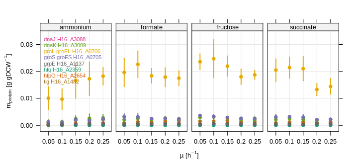

```r
xyplot_errbars(
  data = df_machinery %>% filter(machine == "chaperones"),
  variables = "mass_g_gDCW ~ factor(growth_rate) | substrate",
  groups = "protein", xlab = expression("µ [h"^-1*"]"),
    ylab = expression("m"[protein]*" [g gDCW"^-1*"]")
)
```

## Determining under-utilization of proteins

### Change of enzyme abundance with growth rate

Similar to machinery proteins we can also follow the simulation and actual protein abundance of all (detected) enzymes. We can see that some protein abundances nicely follow a growth-rate dependent manner, in line with predictions of higher flux. One such example are Calvin cycle enzymes for formatotrophic growth. However, for the same enzymes we see that no abundance is predicted under heterotrophic conditions because of missing flux through the pathway, but in fact the proteins are expressed in high abundance, often in a growth-rate dependent manner.

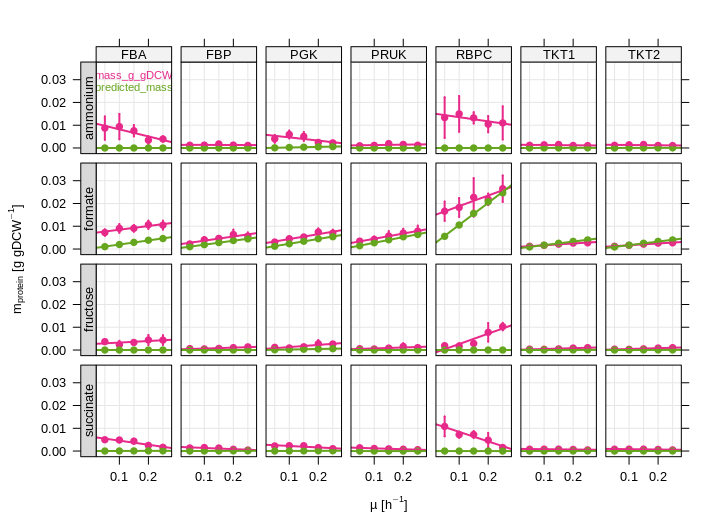

```r
# Plot Calvin cycle reactions as example
plot_calvin <- df_prot_comp %>%

  # select only subset of reactions
  filter(reaction_id %in% c("PRUK", "RBPC", "PGK", "GAPDH", "FBA", "FBP", "TKT1", "TKT2")) %>%

  xyplot_errbars(
    variables = "mass_g_gDCW + predicted_mass_g_gDCW ~
      factor(growth_rate) | reaction_id * substrate",
    scaleoptions = list(alternating = FALSE, x = list(at = c(2,4))),
    xlab = expression("µ [h"^-1*"]"),
    ylab = expression("m"[protein]*" [g gDCW"^-1*"]"),
    lmline = TRUE) %>% useOuterStrips

print(plot_calvin)
```

It is clear from the previous analysis that the cells maintain proteins even if they are not or only marginally utilized. The actually utilized proteome is minimal under strong substrate limitation. The next section will try to quantify the **under-utilization of enzymes** by comparing the minimal protein requirement (simulation) versus experimentally determined protein abundance.

Note that this analysis only includes enzymes that are **actually utilized by the model** under some condition, not all proteins included in the model or all experimentally quantified proteins. This is covered in the R notebook **Ralstonia_variability_analysis**.

### Under-utilization of enzymes

```
number of items to replace is not a multiple of replacement length
```

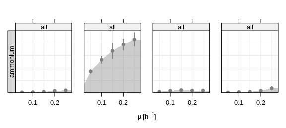

```r
plot_calvin_util <- df_prot_comp %>%

  # filter set of enzymes
  filter(reaction_id %in% c("PRUK", "RBPC", "PGK", "GAPDH", "FBA", "FBP", "TKT1", "TKT2")) %>%

  # calculate protein utilization
  group_by(substrate, growth_rate, replicate) %>%
  summarize(
    mass = sum(mass_g_gDCW, na.rm = TRUE),
    predicted_mass = sum(predicted_mass_g_gDCW, na.rm = TRUE),
    percent_utilization = predicted_mass/(mass)
  ) %>%

  # add pseudo enzyme group
  mutate(enzyme = "all") %>%

  # remove 1 non-quantified replicate
  filter(!(substrate == "fructose" & growth_rate == 0.1 & replicate == "R2")) %>%

  # plot
  xyplot(percent_utilization ~ factor(growth_rate) | enzyme * substrate, .,
    par.settings = custom.colorblind(), ylim = c(0, 1),
    scales = list(alternating = FALSE, y = list(draw = FALSE), x = list(at = c(2,4))),
    xlab = expression("µ [h"^-1*"]"), ylab = "",
    as.table = TRUE, between = list(x = 0.5, y = 0.5),
    pch = 19, lwd = 2, layout = c(1, 4),
    panel = function(x, y, ...) {
      panel.grid(h = -1, v = -1, col = grey(0.9))
      x_mean = unique(x); y_mean = tapply(y, x, mean)
      panel.xyarea(c(0, x_mean, 6), c(0, y_mean, tail(y_mean, 1)),
        lty = 0, col = grey(0.6, alpha = 0.5), ...)
      panel.errbars(x, y, ewidth = 0, col = grey(0.5), ...)
    }
  ) %>% useOuterStrips

print(update(plot_calvin_util, layout = c(4,1)))
```

The following plot is a summary of underutilized enzyme mass *per condition*. Included are only reactions that carry flux under at least one condition or growth rate (that means reactions that never carry flux in any simulation are removed).

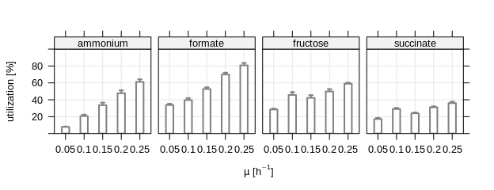

```r
plot_underutil_by_cond <- df_prot_comp %>% group_by(reaction_id) %>%
  filter(sum(predicted_mass_g_gDCW) > 0) %>%

  # summarize utilization per substrate and growth rate
  group_by(substrate, substrate_uptake_rate, growth_rate, replicate) %>%
  summarize(
    mass = sum(mass_g_gDCW, na.rm = TRUE),
    predicted_mass = sum(predicted_mass_g_gDCW, na.rm = TRUE),
    percent_utilization = predicted_mass/(mass)
  ) %>%

  # remove 1 non-quantified replicate
  filter(!(substrate == "fructose" & growth_rate == 0.1 & replicate == "R2")) %>%

  xyplot(100*percent_utilization ~ factor(growth_rate) | substrate, .,
    par.settings = custom.colorblind(),
    xlab = expression(µ*" [h"^-1*"]"),
    ylab = "utilization [%]", ylim = c(0, 100),
    scales = list(alternating = FALSE), as.table = TRUE,
    between = list(x = 0.5, y = 0.5), col = grey(0.5),
    ewidth = 0.2, lwd = 2, layout = c(4, 1),
    panel = function(x, y, errors, ...) {
      panel.grid(h = -1, v = -1, col = grey(0.9))
      panel.barplot(x, y, ...)
    }
  )

print(plot_underutil_by_cond)
```

The most interesting figure is probably a comparison between different pathways. For this purpose we can use the unambiguous pathway annotation for each reaction contained in the genome scale model. Each reaction is mapped to one pathway only, however, the gene associated to this reaction can be associated with other reactions and then the protein mass is shared/distributed between those. Included are only reactions that carry flux under at least one condition or growth rate (that means reactions that never carry flux in any simulation are removed). For this figure **only the highest tested growth rate** µ = 0.25 h-1 was selected.

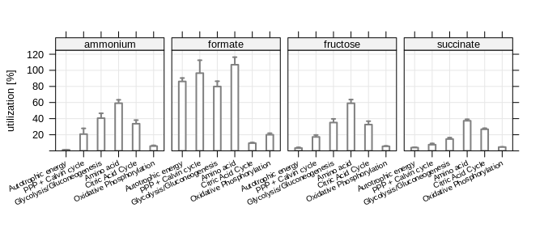

```r
plot_underutil_by_pw <- df_prot_comp %>%

  # filter out all reactions that never carry flux under any condition
  group_by(reaction_id) %>% filter(sum(predicted_mass_g_gDCW) > 0) %>%
  filter(growth_rate == 0.25) %>%

  # summarize utilization per pathway
  group_by(substrate, model_group_basic, replicate) %>%
  summarize(
    mass = sum(mass_g_gDCW, na.rm = TRUE),
    predicted_mass = sum(predicted_mass_g_gDCW, na.rm = TRUE),
    percent_utilization = predicted_mass/(mass)
  ) %>%

  # filter out uninformative group
  filter(model_group_basic != "Other") %>%

  xyplot(100*percent_utilization ~ model_group_basic %>% factor(., unique(.)[c(2,6,4,1,3,5)]) | substrate, .,
    par.settings = custom.colorblind(),
    xlab = "", ylab = "utilization [%]", ylim = c(0, 125),
    scales = list(alternating = FALSE, x = list(cex = 0.6, rot = 25)), as.table = TRUE,
    between = list(x = 0.5, y = 0.5), col = grey(0.5),
    ewidth = 0.2, lwd = 2, layout = c(4, 1),
    panel = function(x, y, errors, ...) {
      panel.grid(h = -1, v = -1, col = grey(0.9))
      panel.barplot(x, y, ...)
    }
  )

print(plot_underutil_by_pw)
```

### Growth and housekeeping related proteins are 10x more abundant

The next task is to identify trends in protein abundance for simulation and experimental results. One completely supervised strategy is for example the summary of each reaction’s protein abundance over growth rate by fitting a linear regression model. We can then coarsely cluster (or hand pick) groups of proteins that will

- increase in simulation, increase in experiment (TRUE POSITIVE)
- remain constant in simulation, decrease/are constant in experiment (TRUE NEGATIVE)
- remain constant in simulation, increase in experiment (FALSE POSITIVE)
- increase in simulation, decrease/are constant in experiment (FALSE NEGATIVE)

One additional layer of complexity is that this analysis can be performed for all four available substrate limitations. The individual trends for one or the other limitation might be different for the same protein/reaction. We can group the data by reaction and substrate limitation and fit a model over five growth rates and four replicates (20 data points). The slope, intercept and ANOVA p-value can be extracted for experimental protein abundance. For model simulations, the slope is sufficient as intercept is likely zero, and p-value unnecessary to determine due to the inherent linearity of model predictions versus growth rate.

```r
df_clusters <- df_prot_comp %>%

  ungroup %>%
  filter(!(is.na(mass_g_gDCW) | is.na(substrate))) %>%

  group_by(model_group_basic, model_group, reaction_id, substrate) %>%
  arrange(desc(growth_rate)) %>%
  summarize(
    average_mass_g_gDCW = mean(mass_g_gDCW[17:20], na.rm = TRUE),
    lin_reg_slope = summary(lm(mass_g_gDCW ~ growth_rate))$coef[2],
    lin_reg_pvalue = summary(lm(mass_g_gDCW ~ growth_rate))$coef[8],
    model_slope = summary(lm(predicted_mass_g_gDCW ~ growth_rate))$coef[2]
  ) %>%

  # manual 'clustering' based on protein vs growth rate slope
  mutate(cluster = case_when(
    lin_reg_slope >  0 & model_slope >  0 ~ "growth function",
    lin_reg_slope <= 0 & model_slope <= 0 ~ "readiness function",
    lin_reg_slope >  0 & model_slope <= 0 ~ "unmodeled growth function",
    lin_reg_slope <= 0 & model_slope >  0 ~ "housekeeping function"
  ))
```

According to these definitions, we can for example investigate some properties of the reactions/proteins within each group. One simple thing to look at first is the distribution of highly and lowly abundant proteins within these groups. The following plot shows that –with very high significance of `p <= 10^-18`– readiness and unmodeled/unknown growth functions are on average much lower abundant, up to 10 times.

```
p-value for comparison of  1
 with  growth housekeeping readiness unmodeled growth  =  1 0.05988554 1.115615e-68 7.119492e-129
```

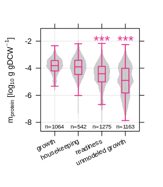

```r
boxplot_colorblind <- custom.colorblind()
boxplot_colorblind$box.rectangle$lwd = 1.5
boxplot_colorblind$box.umbrella$lwd = 1.5


plot_underutil_clusters <- xyplot(log10(average_mass_g_gDCW) ~
      factor(gsub(" function", "", cluster)),
    df_clusters %>% filter(average_mass_g_gDCW != 0),
    par.settings = boxplot_colorblind,
    horizontal = FALSE, do.out = FALSE,
    xlab = "", ylab = expression("m"[protein]*" [log"[10]*" g gDCW"^-1*"]"),
    scales = list(alternating = FALSE, x = list(rot = 25, cex = 0.7)),
    between = list(x = 0.5, y = 0.5),
    panel = function(x, y, ...) {
      panel.grid(h = -1, v = -1, col = grey(0.9))
      panel.violin(x, y, lwd = 0, col = grey(0.6, 0.5), box.width = 0.7, ...)
      panel.bwplot(x, y, pch = "|", box.width = 0.3, ...)
      panel.pvalue(x, y, cex = 0.7, fixed_pos = -0.6, verbose = TRUE, ...)
      panel.text(unique(x), -8.3, labels = paste0("n=", table(x)), cex = 0.6)
    }
  )

print(plot_underutil_clusters)
```

How are the mean values distributed for the four conditions? We can summarize them and then see that *readiness* or *unmodeled growth*-related protein abundance are indeed around 5x and 10x lower than *growth*-related protein abundance, respectively. This analysis does not include growth-related *machinery* proteins such as ribosomes, but solely metabolic enzymes.

The differences are highly significant despite a similar number of reactions associated to one or the other group. While typical growth-related reactions are indeed mainly collected in *growth function*, some amino acid biosynthesis related reactions end up in the last group, *unmodeled growth*. Those correlate with growth in experiment, but are not used in the model.

```r
df_clusters %>% group_by(substrate, cluster) %>%
  filter(average_mass_g_gDCW != 0) %>%
  summarize(mean_mass = 10^mean(log10(average_mass_g_gDCW))) %>%
  spread(cluster, mean_mass)
```

| substrate | growth function | housekeeping function | readiness function | unmodeled growth function |
| --- | --- | --- | --- | --- |
| ammonium | 1.452945e-04 | 1.440404e-04 | 3.432319e-05 | 1.024855e-05 |
| formate | 1.558144e-04 | 1.193302e-04 | 3.784570e-05 | 8.091419e-06 |
| fructose | 9.566083e-05 | 9.403952e-05 | 1.604747e-05 | 1.933694e-05 |
| succinate | 1.373854e-04 | 7.787446e-05 | 3.158389e-05 | 1.128955e-05 |

### Enrichment of functional pathways per group

We try an overrepresentation analysis (ORA) using the hypergeometric test. This requires some careful design of the important sample groups. Every analysis is first grouped by substrate, then we add a hypergeometric test for every combination of substrate, cluster, and pathway. An analogy here is an urn filled with black and white balls. If we draw balls N times, how likely is it that we end up drawing more than X white balls (ORA) / less than Y white balls (URA).

```r
df_ORA <- df_clusters %>%

  # group by model pathway annotation
  group_by(substrate, model_group_basic, cluster) %>%

  # summarize number of reactions annotated with a certain function
  filter(average_mass_g_gDCW != 0) %>%
  summarize(reactions_per_group = length(reaction_id)) %>%

  # determine key numbers for hypergeomtric test:
  # total number of reactions per model group ('white balls')
  group_by(substrate, cluster) %>%
  mutate(n_reactions_total = sum(reactions_per_group)) %>%

  # total number of all reactions together ('black balls'+'white balls')
  group_by(substrate) %>%
  mutate(n_total = sum(reactions_per_group)) %>%

  group_by(substrate, model_group_basic) %>%
  mutate(n_drawn = sum(reactions_per_group)) %>%

  # determine significance of over- and underrepresentation
  mutate(hypgeo_pvalue_OR = phyper(
    reactions_per_group, # white balls drawn
    n_reactions_total, # total number white balls
    n_total-n_reactions_total, # total number black balls
    n_drawn, lower.tail= FALSE) # total number of balls drawn
  )

head(df_ORA)
```

| substrate | model_group_basic | cluster | reactions_per_group | n_reactions_total | n_total | n_drawn | hypgeo_pvalue_OR |
| --- | --- | --- | --- | --- | --- | --- | --- |
| ammonium | Amino acid | growth function | 66 | 224 | 1010 | 234 | 0.004984678 |
| ammonium | Amino acid | housekeeping function | 33 | 155 | 1010 | 234 | 0.687550572 |
| ammonium | Amino acid | readiness function | 87 | 373 | 1010 | 234 | 0.432225563 |
| ammonium | Amino acid | unmodeled growth function | 48 | 258 | 1010 | 234 | 0.974482825 |
| ammonium | Autotrophic energy | housekeeping function | 1 | 155 | 1010 | 15 | 0.696530822 |
| ammonium | Autotrophic energy | readiness function | 10 | 373 | 1010 | 15 | 0.004342283 |

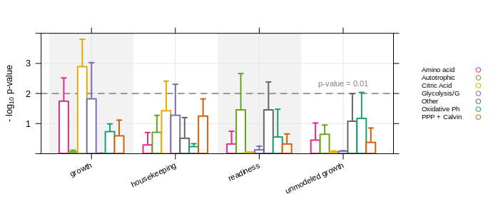

```r
plot_pathways_clusters <- xyplot(-log10(hypgeo_pvalue_OR) ~ factor(gsub(" function", "", cluster)), df_ORA,
    groups = substr(model_group_basic, 1, 12), beside = TRUE, origin = 0.01,
    par.settings = boxplot_colorblind, ylim = c(0, 4),
    horizontal = FALSE, do.out = FALSE, lwd = 2,
    auto.key = list(space = "right", cex = 0.6),
    xlab = "", ylab = expression("- log"[10]*" p-value"),
    scales = list(alternating = FALSE, x = list(rot = 25, cex = 0.7)),
    between = list(x = 0.5, y = 0.5),
    panel = function(x, y, ...) {
      panel.rect(0.5,0,1.5,4, col = grey(0.95), lty = 0)
      panel.rect(2.5,0,3.5,4, col = grey(0.95), lty = 0)
      panel.grid(h = -1, v = -1, col = grey(0.9))
      panel.abline(h = 2, col = grey(0.6), lty = 2, lwd = 2)
      panel.text(4, 2.1, labels = "p-value = 0.01", col = grey(0.5),
        cex = 0.7, pos = 3)
      panel.barplot(x, y, ewidth = 0.055, ...)
    }
  )

print(plot_pathways_clusters)
```

## Yield-growth rate tradeoff under mixotrophic growth?

It was experimentally observed before that *R. eutropha* expresses Rubisco and other *cbb*-operon located genes even on growth on fructose or other heterotrophic substrates. Bowien et al., 1990, show that Rubisco activity can be found under growth on fructose, but not on pyruvate. [Dangel & Tabita, 2015](https://jb.asm.org/content/197/22/3488), review the regulation by CbbR type regulators among others also in *R. eutropha* and mention that citrate also leads to activation of *cbb* expression. They hypothesize that ribulose bisphosphate (RuBP) is an activating effector while other central metabolism intermediates such as phosphoenol pyruvate (PEP) are repressing effector molecules. It was speculated in Bowien et al. that regulation by cbbR might actually be a repression-derepression rather than activation, which means that the default state would be a bound cbbR repressing the *cbb* operon. However it became clear that this is not the case. [Shimizu et al., 2015](http://www.nature.com/articles/srep11617), knocked the cbbR gene out and the result was reduced expression of *cbb* genes by 100 fold. This proves that cbbR is a required activator and not a repressor of cbb, otherwise cbbR deletion would lead to constitutive activation of cbb expression.

They same group speculated in their study that the additional Rubisco expression could have a benefit for carbon yield, specifically for product yield of PHB. They show that PHB from the WT contains slightly more 13C labeled mass (and total mass) than the cbbR and cbbS/L knockouts. This means that the cell would have a (product or biomass) yield advantage by Rubisco expression on fructose, so called mixotrophic growth.

The following section tests the hypothesis of a yield-growth rate tradeoff with the resource allocation model. First simulation data from the RBA model is imported

```r
#adjust path
mixotroph_dir <- gsub("substrate_limitation", "mixotrophy", simulation_dir)

# read simulation results
df_mixflux <- read_rba_result(list.files(mixotroph_dir, pattern = "fluxes_.*.tsv$", full.names = TRUE))
df_mixmacr <- read_rba_result(list.files(mixotroph_dir, pattern = "macroprocesses_.*.tsv", full.names = TRUE))

# rename column
df_mixmacr <- df_mixmacr %>% rename(CO2_refixation = sim_run)
df_mixflux <- df_mixflux %>% rename(CO2_refixation = sim_run)
```

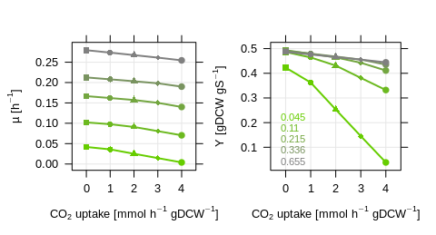

```r
plot_mixo_mu <- lapply(c("mu", "yield"), function(keys) {

  if (keys == "mu") ylabel <- expression("µ [h"^-1*"]")
  if (keys == "yield") ylabel <- expression("Y [gDCW gS"^-1*"]")

  xyplot(value ~ factor(CO2_refixation),
    filter(df_mixmacr, key == keys),
    groups = carbon_conc, col = colorRampPalette(c("#66CD00", grey(0.5)))(5),
    between = list(x = 0.5, y = 0.5), type = "b", lwd = 2,
    par.settings = custom.colorblind(),
    z = filter(df_mixmacr, key == keys) %>% pull(CO2_refixation) %>% as.numeric,
    xlab = expression("CO"[2]*" uptake [mmol h"^-1*" gDCW"^-1*"]"),
    ylab = ylabel,
    panel = function(x, y, z, ...) {
      panel.grid(h = -1, v = -1, col = grey(0.9))
      panel.symbols(x, y, z+15, ...)
      if (keys == "yield") panel.key(..., corner = c(0.02, 0.05),
        cex = 0.7, points = FALSE)
    }
  )
})

print(plot_mixo_mu[[1]], position = c(0,0,0.53,1), more = TRUE)
print(plot_mixo_mu[[2]], position = c(0.47,0,1,1))
```

There is no increase in growth rate or yield with additional CO<sub>2</sub> fixation according to the RBA model. The yield is in fact calculated based on the growth rate µ and the substrate uptake rate qS. Yield and growth rate depend on each other in the relation Y [gDCW/gS] = µ [h-1] / qS [gS gDCW-1 h-1].

Since only the initial substrate concentration is constrained, the model could predict a lower substrate uptake rate or lower CO2 emission per biomass in order to reach a yield increase. However this was not the case under any simulation, see below for details of specific metabolites.

The model seems to predict a high-yield phenotype already. If CO2 re-fixation would have had an advantage for growth, it might have been detected earlier depending on the protein costs for the respective pathway. Before a final verdict, we can follow the fate of the fixed CO2 through the metabolism.

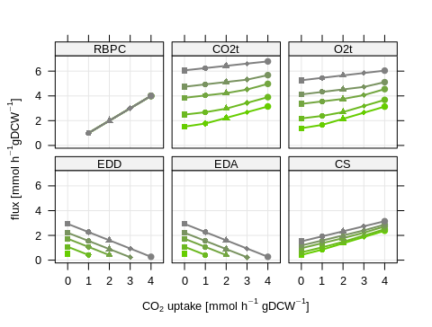

```r
enzyme_selection <- c("CO2t", "RBPC", "EDD", "EDA", "CS", "O2t")

plot_mixo_enz <- xyplot(abs(value) ~ as.factor(CO2_refixation) |
    factor(key, unique(key)[c(6,2,1,4,5,3)]),
  filter(df_mixflux, key %in% enzyme_selection),
  groups = carbon_conc, layout = c(3,2),
  scales = list(alternating = FALSE),
  type = "b", lwd = 2,
  z = filter(df_mixflux, key %in% enzyme_selection) %>%
    pull(CO2_refixation) %>% as.numeric,
  between = list(x = 0.5, y = 0.5), as.table = TRUE,
  par.settings = custom.colorblind(),
  col = colorRampPalette(c("#66CD00", grey(0.5)))(5),
  xlab = expression("CO"[2]*" uptake [mmol h"^-1*" gDCW"^-1*"]"),
  ylab = expression("flux [mmol h"^-1*"gDCW"^-1*"]"),
  panel = function(x, y, z, ...) {
    panel.grid(h = -1, v = -1, col = grey(0.9))
    panel.symbols(x, y, z+15, ...)
  }
)

print(plot_mixo_enz)
```

### Conclusion

It becomes clear that yield and growth rate decrease, and not increase, with additional CO2 fixation, because:

- energy requirement for CO2 fixation leads to lower flux through ED pathway, but higher flux through TCA
- this is in order to generate the required NADH/ATP for CO2 fixation
- respiration and O2 consumption also increases with forced mixotrophic growth
- there is no net reduction of CO2 emission. In fact cells emit more CO2 even when they fix some of it due to increased energy requirement
- storing some of the fixed CO2 as PHB would not increase biomass yield as additional energy requirement still persists
- cells should not be able to make more PHB using this strategy, regardless of biomass yield. If acetyl-CoA is drained for PHB, even less energy is made available through TCA and OXPHOS.